# Análisis Exploratorio de los Logs del Aula Virtual: Grupo E

Eva Gamón

Universidad de Valencia

Marina Moros

Universidad de Valencia

Irene Pérez

Universidad de Valencia

Maria Martínez

Universidad de Valencia

Tomas Payás

Universidad de Valencia

2026-05-15

Abstract

Este trabajo analiza el comportamiento de los estudiantes mediante los registros de actividad del Aula Virtual, aplicando un Análisis Exploratorio de Tratamiento de Datos (TD) con R y Tidyverse. El objetivo es extraer patrones de interacción y transformar datos brutos en información útil.

# 1 Introducción

En la era digital actual, las plataformas de aprendizaje virtual como el Aula Virtual se han convertido en el núcleo operativo de la educación universitaria. Estas plataformas no solo facilitan el acceso a los materiales y la entrega de tareas, sino que también generan un rastro digital exhaustivo de las interacciones de los usuarios mediante archivos de registro o *logs*.

Este proyecto tiene como objetivo principal poner en práctica los conocimientos de Análisis Exploratorio de Datos adquiridos durante la asignatura de “Tratamiento de los Datos” del Grado en Ciencia de Datos. Para llevar a cabo este análisis, trabajaremos con un conjunto de datos real proporcionado por el profesor de la asignatura: los *logs* anonimizados del Aula Virtual de esta misma asignatura, correspondientes al curso académico 2024-2025.

Mediante el uso del lenguaje de programación R y, en particular, del ecosistema *tidyverse* (con librerías como `dplyr`, `tidyr` y `ggplot2`), realizaremos un proceso completo de importación, limpieza, adecuación y visualización de los datos. El propósito es extraer patrones de comportamiento subyacentes que nos permitan entender cómo interactúan los alumnos con la plataforma.

A lo largo de este documento, plantearemos y daremos respuesta a una serie de preguntas clave, tales como la distribución temporal de las conexiones, los recursos más consultados o los picos de actividad. De este modo, buscamos transformar un conjunto de datos en bruto en información útil y visualmente interpretable.

# 2 Material y métodos

En esta fase se ha llevado a cabo la importación de los datos en bruto para convertirlos en un conjunto de datos técnicamente correcto. Para ello, se han renombrado las variables conflictivas y se ha convertido la variable temporal a un formato de fecha válido utilizando la librería lubridate. Como se puede observar en la Tabla 1, los datos han sido importados y preprocesados correctamente para su posterior análisis exploratorio.

```r
# Importación de los datos
archivo_datos <- "data/logs_moodle_anon.csv"
datos_brutos <- read.csv(archivo_datos, fileEncoding = "UTF-8")

# Preparación y tratamiento de fechas
datos_logs <- datos_brutos %>%
  # Renombramos columnas (sin espacios)
  rename(
    Usuario = Nombre.completo.del.usuario,
    Contexto = Contexto.del.evento,
    Evento = Nombre.evento
  ) %>%
  # Tratamiento de fecha con lubridate
  mutate(
    Fecha_aux = dmy_hms(Hora),
    Fecha_texto = format(Fecha_aux, "%d/%m/%Y")
  )

# Comprobación
kable(head(datos_logs, 5), caption = "Primeros registros de la base de datos") %>% kable_styling(latex_options = "scale_down")
```

Primeros registros de la base de datos

| Hora | Usuario | Usuario.afectado | Contexto | Componente | Evento | Descripción | Origen | Dirección.IP | Fecha_aux | Fecha_texto |
| --- | --- | --- | --- | --- | --- | --- | --- | --- | --- | --- |
| 3/03/26, 10:59:04 | U0072 | NA | Curso: 2024-25 Tractament de les dades Gr.A-T (36423) | Registros | Informe de registro visualizado | The user with id ‘22872’ viewed the log report for the course with id ‘85837’. | web | 2001:720:1014:88:0:0:a:6b7 | 2026-03-03 10:59:04 | 03/03/2026 |
| 3/03/26, 10:58:57 | U0072 | NA | Curso: 2024-25 Tractament de les dades Gr.A-T (36423) | Registros | Informe de registro visualizado | The user with id ‘22872’ viewed the log report for the course with id ‘85837’. | web | 2001:720:1014:88:0:0:a:6b7 | 2026-03-03 10:58:57 | 03/03/2026 |
| 3/03/26, 10:58:30 | U0072 | NA | Curso: 2024-25 Tractament de les dades Gr.A-T (36423) | Actividad del curso | Informe de actividad visto | The user with id ‘22872’ viewed the outline activity report for the course with id ‘85837’. | web | 2001:720:1014:88:0:0:a:6b7 | 2026-03-03 10:58:30 | 03/03/2026 |
| 3/03/26, 10:57:28 | U0072 | NA | Curso: 2024-25 Tractament de les dades Gr.A-T (36423) | Actividad del curso | Informe de actividad visto | The user with id ‘22872’ viewed the outline activity report for the course with id ‘85837’. | web | 2001:720:1014:88:0:0:a:6b7 | 2026-03-03 10:57:28 | 03/03/2026 |
| 3/03/26, 10:57:09 | U0072 | NA | Curso: 2024-25 Tractament de les dades Gr.A-T (36423) | Sistema | Curso visto | The user with id ‘22872’ viewed the course with id ‘85837’. | web | 2001:720:1014:88:0:0:a:6b7 | 2026-03-03 10:57:09 | 03/03/2026 |

# 3 Figuras y tablas numeradas y referenciadas.

En este proyecto utilizaremos figuras y tablas para poder interpretar de una manera más clara y visual la información obtenida a partir de los datos analizados.

## 3.1 Tablas:

Queremos mostrar los 5 eventos que más aparecen, identificando así las acciones que los usuarios realizan de manera más habitual.

Frecuencia de eventos registrados

| Evento | Cantidad |
| --- | --- |
| Módulo de curso visto | 23535 |
| Curso visto | 20430 |
| Usuario calificado | 12846 |
| Se ha visualizado el estado de la entrega. | 9388 |
| Intento de cuestionario visualizado | 3877 |

En la Tabla $\ref{fig:tabla-eventos}$ vemos los eventos más habituales entre los usuarios.

## 3.2 Figura:

Vamos a crear un diagrama de barras que nos permite visualizar cuáles son los tipos de eventos más frecuentes

En la Figura $\ref{fig:figura-eventos}$ podemos observar cuáles son los eventos más frecuentes entre los usuarios.

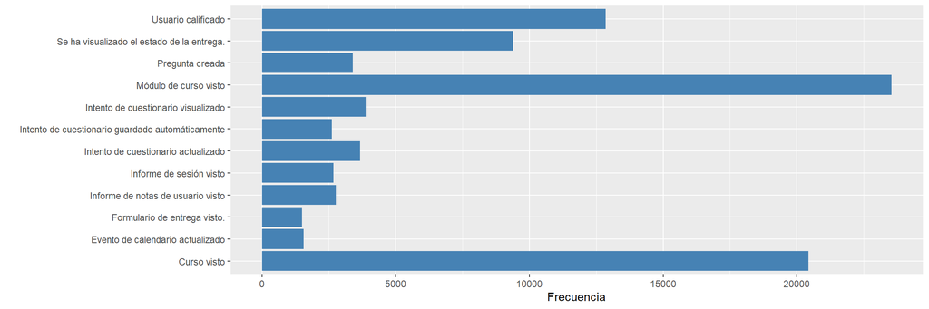

Diagrama de barras de los eventos más frecuentes

# 4 Exploración y Visualización

Una vez que los datos han sido organizados en una estructura adecuada y se ha verificado su consistencia,comienza una fase clave del análisis: la exploración. En este punto, el objetivo no es todavia confirmar conclusiones, sino observar,comparar y cuestionar la información otorgada. A partir del conjunto de datos dado nos surgen varias hipótesis provisionales sobre posibles tendencias,relaciones o comportamientos. En el siguiente apartado se expondrán dichas preguntas claves para la exploración de los datos

1.¿En que hora existe una mayor actividad por parte de los alumnos ?

2.¿Se generan picos antes de la entrega de un proyecto?

3.¿Qué usuarios son más activos (mayor número de eventos)?

4.¿Existen usuarios con comportamiento atípico (muy alta o muy baja actividad)?

5.¿Existe relación entre el dispositivo empleado y la actividad realizada?

6.¿Que actividades o recursos generan más interacciones?

7.¿Hay registros realizados en horas “extrañas” (ej. 4:00 AM)? ¿Son usuarios aislados o un patrón común en época de exámenes?

8.¿Se detectan múltiples IPs para un mismo usuario en un corto periodo de tiempo?

9.¿Hay eventos de error o acciones fallidas recurrentes en los logs?

10.¿Existe alguna evolución en la actividad de un mismo usuario a lo largo del año (de menos a más o de más a menos)? ¿A que puede deberse esto?

11.¿Hay una diferencia notoria entre las actividades registradas en dias lectivos y las registradas los fines de semana?

12.¿Que franjas horarias muestran una mayor concentración de usuarios al mismo tiempo?

13.¿Cuál es la proporción entre el número de actividades pasivas (entrar, ver) y las activas (entregar, editar)?

14.¿Existen usuarios que solo acceden en momentos muy concretos? (Ej. previos a entrega o a exámenes)

15.¿En horario lectivo se detecta menor actividad desde el móvil o es indiferente?

16.¿Hay más actividad en días laborales o en fin de semana? ¿Varia esta proporción en momentos concretos? (Ej. época de exámenes)

## 4.1 Análisis univariante

En nuestro data frame observamos la predominancia de variables de tipo string o factor, de modo que las tablas realizadas no mostrarán estadísticos descriptivos. En este caso, se centraran en frecuencias, porcentajes y descripciones.

Descripción de las variables

| Variable | Tipo | Descripción |
| --- | --- | --- |
| Usuario | Factor | Identificador anónimo del alumno |
| Contexto | String | Nombre del curso o tarea donde ocurre la acción |
| Componente | Factor | Módulo del sistema (Tarea, Cuestionario, Sistema) |
| Evento | Factor | Acción específica realizada por el usuario |
| Dirección.IP | String | Dirección desde la que se conecta |
| hora_dia | Entero | Hora del día en formato 24h |

Como se puede observar en la Tabla $\ref{tab:tabla-variables}$, existe una predominancia de variables de tipo string o factor.

Análisis de valores faltantes por variable

| Variable | ValoresFaltantes |
| --- | --- |
| Hora | 0 |
| Usuario | 0 |
| Usuario.afectado | 69346 |
| Contexto | 0 |
| Componente | 0 |
| Evento | 0 |
| Descripción | 0 |
| Origen | 0 |
| Dirección.IP | 2857 |
| Fecha_aux | 0 |
| Fecha_texto | 0 |

Por otro lado, la existencia de valores nulos en variables como “Usuario.afectado” no deben interpretarse como errores, ya que existen múltiples acciones que son individuales y no requieren la implicación de un segundo usuario. Por tanto, el data set es considerado de alta calidad.

Una vez confirmada la integridad del data frame obtenido y analizada la naturaleza de las variables que lo componen procedemos a realizar una análisis descriptivo, en el cual trataremos de identificar los patrones de coportamiento de los estudiantes. Por ende ,analizaremos los picos de actividad y los materiales consultados con mayor frecuencia.

# 5 Análisis de la distribución horaria

Para determinar la franja horaria en la que existe una mayor actividad por parte del alumnado, analizaremos la distribución.Esta nos permite comprender y analizar el comportamiento de los estudiantes.

En este caso contemplaremos tanto la forma de la distribución(Gráfica 1), como el número de interacciones por franjas horarias(Gráfica 2)

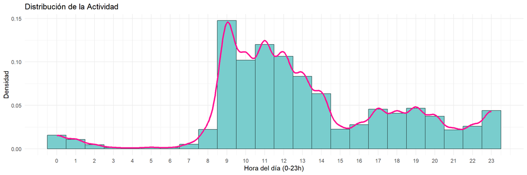

Análisis densidad

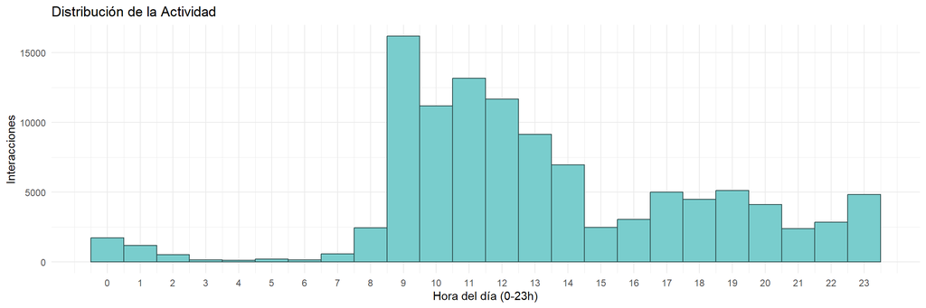

Distribución de la actividad de los usuarios por hora del día

Como se puede observar en las Figura $\ref{fig:grafico-horas}$,el uso de la plataforma presenta una gran variación a lo largo del día. La mayor parte de la actividad se concentra durante la mañana, alcanzando su pico máximo durante las 9:00 horas, podemos observar que en ese instante se registran más de 16.000 eventos. Este comportamiento es coherente con el horario lectivo.

Por otro lado, podemos apreciar como la caída de la actividad durante las horas centrales del mediodía (14:00 - 16:00), seguida de un segundo incremento más moderado durante la tarde y noche (17:00 - 20:00),franja horaria que coincide con el estudio autónomo y trabajo en casa .Finamente, la actividad desciende a patir de la 1:00 AM

### 5.0.1 *Análisis de la evolución temporal*

En este caso aplicaremos otro tipo de enfoque,trataremos con los días. El objetivo es ver la evolución temporal de la actividad y superponer las fechas límite (fechas de entrega) para comprobar visualmente si la actividad se dispara justo antes.

Para realizar este análisis( figura $\ref{fig:picos-entrega}$), se ha explorado el dataset en busca del evento ‘Se ha enviado una entrega’. Con el objetivo de mostrar el comportamiento del alumnado, se ha seleccionado la entrega del proyecto realizada el 26 de mayo de 2025.

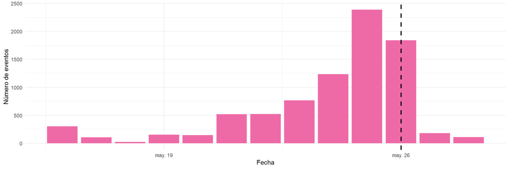

Actividad diaria en los días previos a la entrega final del proyecto (26 de mayo).

# 6 Exploración Usuarios

En este apartado realizaremos un análisis en base al comportamiento de los usuarios de la plataforma.

## 6.1 Análisis frecuencia:usuarios más activos

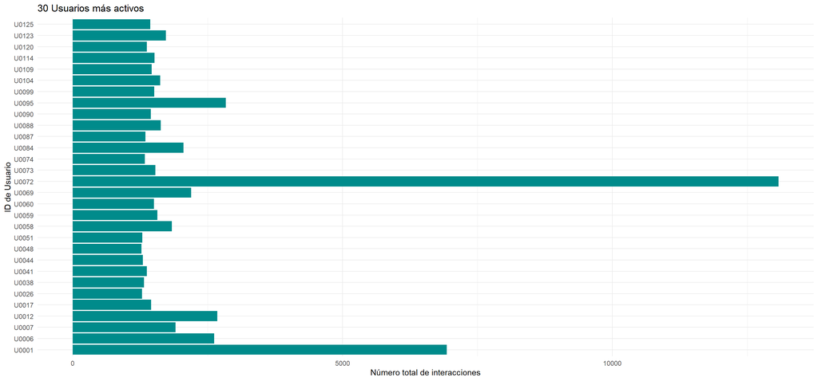

30 usuarios con mayor número de interacciones en la plataforma.

Con el objetivo de analizar la participación por parte del alumnado, hemos identificado los 30 usuarios más activos del conjunto.Como podemos ver en la figura $\ref{fig:grafico-usuarios-activos}$,existe un grupo de alumnos con un número elevado de interacciones,llegando a ser más de 5000.

Este gráfico nos permite diferenciar el alumnado que utiliza la plataforma de forma puntual y aquellos que navegan e interactúan constantemente con el material del curso.

## 6.3 Comportamientos atípicos

Usuarios con comportamiento atípico en número de acciones

| Usuario | total_acciones |
| --- | --- |
| U0072 | 13079 |
| U0001 | 6932 |
| U0095 | 2836 |
| U0012 | 2680 |
| U0006 | 2623 |

Como se observa en la Tabla $\ref{tab:tabla-atipicos}$ , existe un grupo de estudiantes con una actividad excepcionalmente alta. Estos usuarios suelen ser los que consultan repetidamente los materiales o realizan múltiples intentos en las actividades, lo que debe tenerse en cuenta para no sesgar las interpretaciones globales del grupo. Por ejemplo el usuario U0072 destaca con un total de 13079 acciones, seguido por U0001 con 6932 acciones.

# 7 Actividades

En este apartado veremos las diferentes relaciones, iteracciones y comportamientos que tienen las actividades.

## 7.1 Relación entre dispositivo empleado y la actividad realizada

Relación entre el origen y el tipo de evento

| Origen | Evento | total |
| --- | --- | --- |
| web | Módulo de curso visto | 23535 |
| web | Curso visto | 20430 |
| cli | Usuario calificado | 340 |
| web | Usuario calificado | 12506 |
| web | Se ha visualizado el estado de la entrega. | 9388 |
| web | Intento de cuestionario visualizado | 3877 |
| web | Intento de cuestionario actualizado | 3676 |
| web | Pregunta creada | 3395 |
| web | Informe de notas de usuario visto | 2771 |
| web | Informe de sesión visto | 2680 |

En la Tabla $\ref{tab:tabla-origen}$ se aprecia cómo ciertos eventos de consulta son predominantes desde determinados orígenes de conexión, lo que sugiere que el tipo de dispositivo podría condicionar la navegación del usuario. Por ejemplo el origen web con el tipo de evento Módulo de curso visto con 23535.

## 7.2 Actividades/recursos con más iteracciones

Actividades o recursos con más interacciones

| Componente | Evento | total_interacciones |
| --- | --- | --- |
| Sistema | Curso visto | 20430 |
| Tarea | Módulo de curso visto | 12860 |
| Sistema | Usuario calificado | 12846 |
| Tarea | Se ha visualizado el estado de la entrega. | 9388 |
| Cuestionario | Intento de cuestionario visualizado | 3877 |
| Cuestionario | Intento de cuestionario actualizado | 3676 |
| Sistema | Pregunta creada | 3395 |
| Carpeta | Módulo de curso visto | 3310 |
| Cuestionario | Módulo de curso visto | 3234 |
| Usuario | Informe de notas de usuario visto | 2771 |

Tal y como indica la Tabla $\ref{tab:tabla-iteraccion2}$ , los componentes relacionados con la visualización de materiales y la gestión de tareas son los que generan el mayor flujo de datos en los logs analizados.

El componente sistema por ejemplo, con el evento curso visto con un total de iteracciones 20430.

# 8 Estudio de la actividad nocturna en periodos de exámenes.

En este apartado analizaremos si existen accesos al Aula Virtual en horarios poco habituales, el estudio se ha realizado con actividades registradas entre las 00:00 y las 05:00 AM. Será posible analizar si dichos accesos corresponden a casos aislados o, por el contrario, aumentan durante periodos de evaluación.

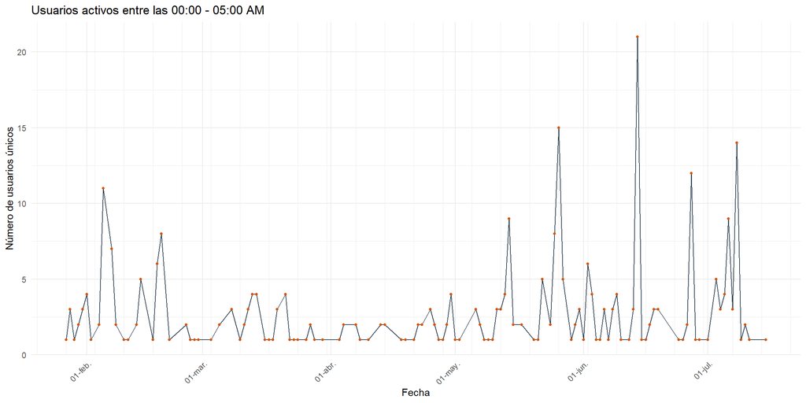

grafico usuarios nocturnos

En el gráfico $\ref{fig:grafico-usuarios-nocturnos}$ muestra la evolución del segundo cuatrimestre en cuanto a la actividad de usuarios en horas “extrañas” (00:00 a 05:00 AM). Se observan claros picos de actividad en algunos periodos del año, especialmente entre los meses de mayo y julio. Mientras que durante el resto del curso la actividad es mínima y podemos atribuirlo a usuarios aislados.

Sin embargo, conforme se aproximan los periodos de evaluación, el número de estudiantes activos durante la madrugada aumenta de manera considerable. Este comportamiento resulta especialmente visible entre los meses de mayo y junio, coincidiendo la época de exámenes.

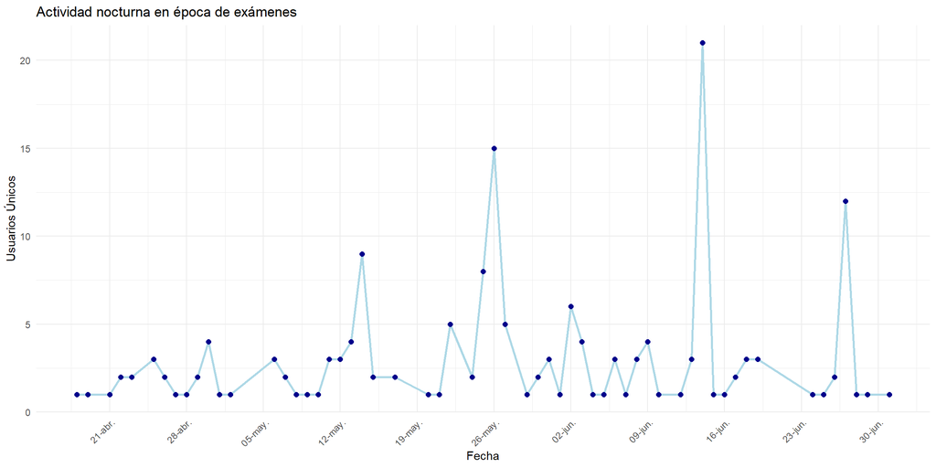

epoca examenes

Como se aprecia en la Figura $\ref{fig:grafico-epoca-examenes}$ , existen varios días concretos donde la actividad nocturna aumenta notablemente. Por ejemplo, alrededor del 26 de mayo y mediados de junio se registran picos superiores a 15 y 20 usuarios conectados respectivamente durante la madrugada.

Por otra parte, se puede ver casos aislados en algunos meses. Por ejemplo entre el 5 de mayo y el 12 de mayo donde la actividad nocturna se reduce a 1 o 2 usuarios por noche.

# 9 Identificación de cambios de dirección IP en cortos periodos de tiempo.

Se ha realizado un análisis para estudiar los posibles cambios de conexión entre los usuarios mediantelas direcciones IP registradas en los accesos del Aula Virtual. Este proceso perimite detectar si un mismo usuario accede desde diferentes redes o dispositivos en intervalos temporales reducidos.

Usuarios con cambios frecuentes de IP

| Usuario | IPs distintas totales | Cambios rápidos de IP |
| --- | --- | --- |
| U0001 | 1248 | 1167 |
| U0006 | 153 | 48 |
| U0003 | 112 | 39 |
| U0102 | 123 | 35 |
| U0012 | 73 | 33 |
| U0058 | 113 | 33 |

Al analizar la Tabla $\ref{tab:tabla-usuarios-ip-distinta}$, se confirma la existencia de accesos desde múltiples direcciones IP en intervalos de tiempo muy reducidos. Destaca especialmente el usuario U0001, que presenta un número muy elevado tanto de direcciones IP distintas como de cambios rápidos de conexión (cada 30 minutos). Sin embargo, en la mayoría de los usuarios los valores observados son considerablemente más moderados.

Estos cambios tan frecuentes se deben a cambios de red (Wifi y datos móviles), el uso de diferentes dispositivos o aquellas redes que son dinámicas.

# 10 Identificación de eventos de errores y acciones fallidas.

Para determinar si existen eventos de error o acciones fallidas recurrentes en los logs del Aula Virtual, realizaremos un análisis de aquellas acciones cuyo nombre contenga términos asociados a errores, fallos o intentos no completados correctamente.

Este análisis puede resultar relevante ya que permite identificar los posibles problemas técnicos o dificultades de uso de la plataforma del Aula Virtual por parte de los usuarios.

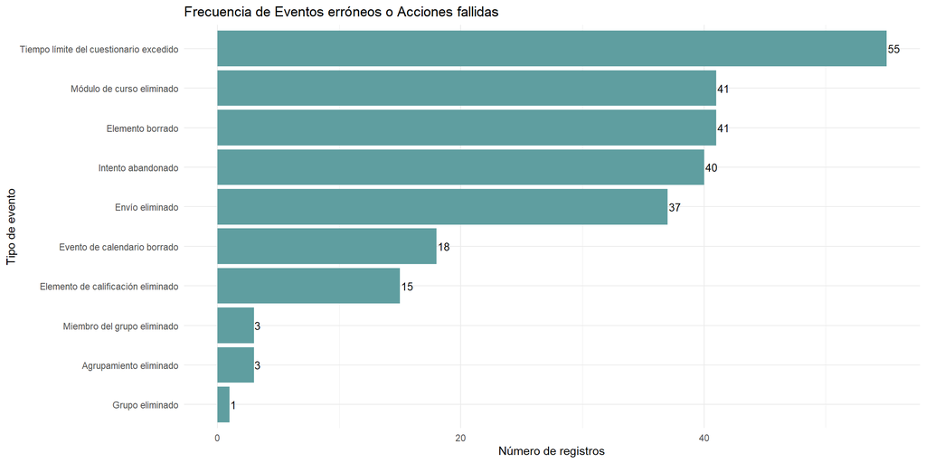

eventos de error más frecuentes.

En el gráfico $\ref{fig:grafico-eventos-erroneos}$ se pueden observar aquellos eventos de errores o acciones fallidas que presentan una mayor frecuencia dentro de los registros del Aula Virtual.

El evento más repetido corresponde a “Tiempo límite del cuestionario excedido”, con un total de 55 registros. También destacan los eventos “Módulo de curso eliminado” y “Elemento borrado”, ambos con 41 registros.

## 10.1 Variación de la actividad anual en casos aislados

Para el análisis de la variación de la actividad de cada usuario a lo largo del año, analizaremos las actividades registradas por cada usuario en los diferentes meses y representaremos en un gráfico de barras los datos de cada mes para poder observar la diferencia entre los meses.

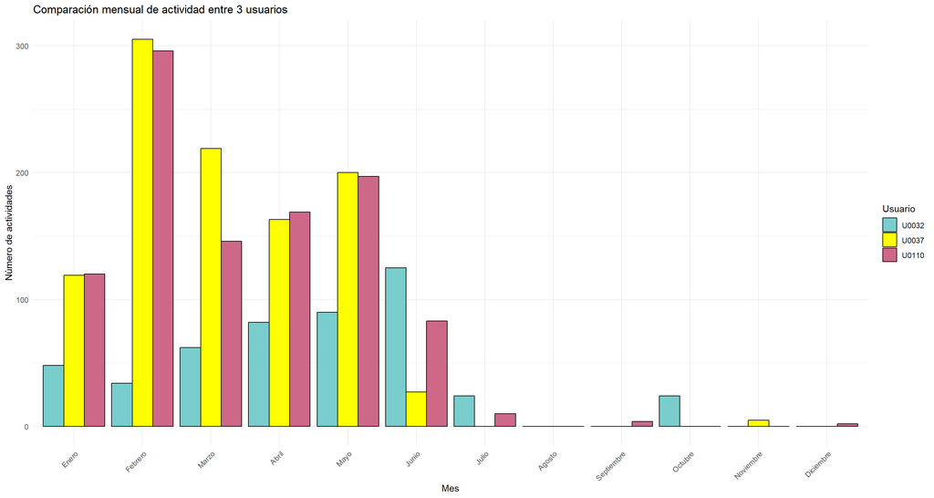

variación actividad anual

Como observamos en el gráfico ($\ref{fig:graficos-actvidad-anual}$), cada usuario presenta una variación anual de la actividad mensual diferente, es decir que ninguno sigue un patrón organizado, ni los usuarios muestran una misma variación entre los meses, por lo que según los datos registrados podemos concluir en que cada usuario realiza una serie de actividades diferentes independientemente de las actividades realizadas por los demás usuarios del registro.

## 10.2 Diferencias de actividad entre días lectivos y fines de semana

Para analizar si existe una diferencia notable entre la actividad registrada en días lectivos y la registrada durante los fines de semana, estudiaremos el número total de eventos generados en cada día. El objetivo es comprobar si los usuarios utilizan el aula virtual principalmente durante la semana, coincidiendo con el calendario académico, o si también muestran actividad relevante durante los sábados y domingos. Para ello, clasificaremos cada registro según el día de la semana y representaremos los resultados en un gráfico comparativo que permita visualizar de forma clara la diferencia entre ambos grupos.

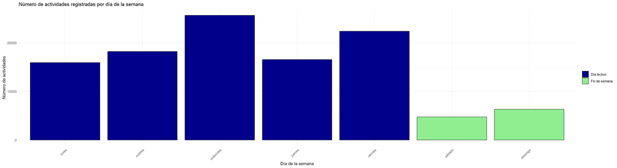

diferencia de actividad

En el gráfico $\ref{fig:dif_dias_fines}$ se observa la distribución de actividades registradas a lo largo de los siete días de la semana. Los días lectivos (de lunes a viernes) concentran la mayor parte de la actividad, lo cual es coherente con el funcionamiento habitual de una asignatura universitaria: los estudiantes suelen acceder al aula virtual coincidiendo con las clases, la realización de tareas y la consulta de materiales.

Por el contrario, los sábados y domingos muestran una actividad considerablemente menor. Este descenso puede deberse a que los estudiantes tienden a desconectar durante el fin de semana o a que la asignatura no plantea entregas ni actividades en esos días. Además, si se observa un pico concreto en algún día específico (por ejemplo, los miércoles), podría estar relacionado con la programación de clases presenciales, la publicación de materiales o la proximidad de fechas de entrega.

En conjunto, el gráfico permite visualizar de forma clara cómo se distribuye la actividad semanal y confirma que el uso de la plataforma sigue un patrón muy ligado al calendario académico, los días lectivos se registran actividades en mayor cantidad y los dias del fin de semana menor.

## 10.3 Variabilidad en la masa de estudiantes por hora

Para analizar qué franjas horarias presentan una mayor variabilidad entre usuarios, estudiaremos cuántos usuarios distintos generan actividad en cada hora del día. Esto nos permitirá identificar si existen horas en las que muchos usuarios diferentes acceden a la plataforma, frente a otras en las que solo unos pocos usuarios realizan acciones. Este análisis es útil para comprender los patrones colectivos de acceso y detectar momentos de mayor diversidad de participación.

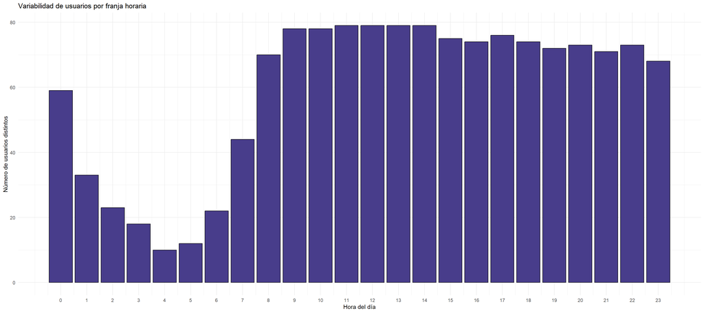

variabilidad

El gráfico $\ref{fig:grafico-variabilidad}$ muestra cuántos usuarios distintos generan actividad en cada hora del día. Las horas con barras más altas representan franjas horarias con mayor variabilidad, es decir, momentos en los que muchos usuarios diferentes acceden a la plataforma. Mientras que las barras más bajas muestran los momentos del día de menor actividad por parte de los estudiantes.

En conjunto, el gráfico $\ref{fig:grafico-variabilidad}$ permite identificar claramente qué franjas horarias presentan mayor diversidad de usuarios activos y cuáles muestran un uso más limitado, proporcionando una visión global del comportamiento colectivo a lo largo del día.

## 10.4 Comportamiento del usuario: Actividades pasivas frente a activas

Para profundizar en la exploración de los usuarios, resulta fundamental conocer qué tipo de uso hacen de la plataforma. Por ello, se procederá a analizar la proporción existente entre el número de actividades pasivas (orientadas a la consulta, como entrar o visualizar material) y las actividades activas (que implican la creación o modificación de contenido, como entregar tareas o editar).

Para dar respuesta a esta cuestión, se ha llevado a cabo una clasificación de los eventos mediante técnicas de procesamiento de texto. Se ha normalizado el texto y buscado raíces de palabras clave para categorizar cada acción, otorgando prioridad a los eventos de creación y excluyendo los eventos neutros o del sistema para asegurar una comparativa directa y rigurosa.

Frecuencia y porcentaje de actividades Pasivas y Activas

| Tipo_Actividad | Cantidad | Porcentaje |
| --- | --- | --- |
| Activa | 28318 | 32.03 |
| Pasiva | 60087 | 67.97 |

Tal y como se muestra en la Tabla $\ref{tab:tabla-proporcion}$, existe una evidente disparidad entre los volúmenes de ambas categorías. Para facilitar la interpretación de estos resultados, se ha generado la siguiente representación gráfica.

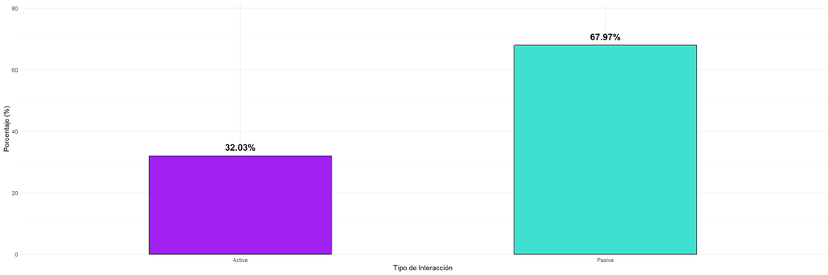

Proporción de actividades pasivas frente a activas en la plataforma.

## 10.5 Identificación de patrones de acceso estacional

Tras analizar la distribución general de la actividad, resulta de gran interés determinar si existe un perfil de estudiante con un comportamiento “estacional”. Es decir, alumnos que no mantienen una interacción constante con el Aula Virtual, sino que concentran gran parte de su actividad en momentos críticos, como los días previos a la entrega final del proyecto (fijada el 26 de mayo).

Para este análisis, hemos definido un “Periodo Crítico” que abarca los 7 días previos a la entrega. Hemos clasificado a los usuarios en dos categorías: **Acceso Puntual**, aquellos cuya actividad semanal triplica la media esperada (concentrando más del 10% de sus clics anuales en esa única semana); y **Acceso Regular**, el resto de usuarios con una participación más constante a lo largo del curso.

Clasificación de usuarios según su estacionalidad ante la entrega.

| Tipo_Usuario | Numero_Usuarios | Porcentaje |
| --- | --- | --- |
| Acceso Puntual | 21 | 24.14 |
| Acceso Regular | 66 | 75.86 |

Como se puede observar en la Tabla $\ref{tab:tabla-estacional}$, al aplicar este criterio de concentración semanal, logramos identificar un segmento de la clase con un perfil de acceso puntual. Aunque un gran grupo de estudiantes mantiene una interacción más regular a lo largo del curso, existe una parte del alumnado que intensifica drásticamente su huella digital ante la proximidad de los plazos de evaluación.

Para visualizar esta segmentación y entender cómo se distribuye la intensidad de la actividad en el periodo crítico, se presenta la siguiente figura.

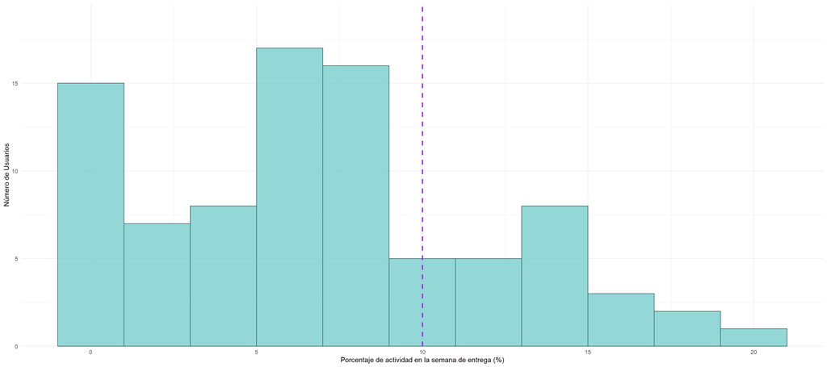

Concentración de la actividad de los usuarios en la plataforma durante periodos muy concretos.

La Figura $\ref{fig:figura-estacional}$ muestra la distribución de los usuarios según el peso que tiene esa semana específica en su actividad total anual. La acumulación de usuarios a la derecha de la línea de corte (marcada en color morado) confirma la existencia de alumnos cuya actividad se dispara bajo la presión evaluativa. Este comportamiento es un indicador claro de una estrategia de aprendizaje basada en la urgencia frente a la constancia continuada.

## 10.6 Análisis del uso de dispositivos según la franja horaria

Para comprender los hábitos de conexión del alumnado, la cuestión plantea si existe una disminución del uso de dispositivos móviles durante el horario lectivo en favor de otras herramientas. Para estructurar la comparativa, definimos el “Horario Lectivo” como la franja comprendida entre las 08:00 y las 14:00 horas, frente al “Horario No Lectivo” (el resto del día).

Mediante funciones de búsqueda y filtrado de texto, rastreamos los registros en busca de las etiquetas asociadas a la aplicación móvil (App, Web Services, Mobile,…) para contrastarlos con los accesos al entorno web estándar.

Distribución absoluta y porcentual del tipo de acceso por franja horaria.

| Horario | Dispositivo | Accesos | Porcentaje |
| --- | --- | --- | --- |
| Horario Lectivo | Ordenador / Web | 70765 | 100 |
| Horario No Lectivo | Ordenador / Web | 38981 | 100 |

Como se detalla en la Tabla $\ref{tab:tabla-dispositivos}$, los resultados extraídos del conjunto de datos son tajantes y revelan una limitación técnica de los propios registros de la plataforma: no existen trazas de actividad móvil. El 100% de las interacciones, tanto por la mañana como por la tarde, constan en el sistema como tráfico Web/Ordenador.

Ante la imposibilidad de comparar porcentajes de dispositivos (dado que la variable es constante), el análisis debe centrarse en el volumen total de actividad que soporta la plataforma en cada una de estas franjas.

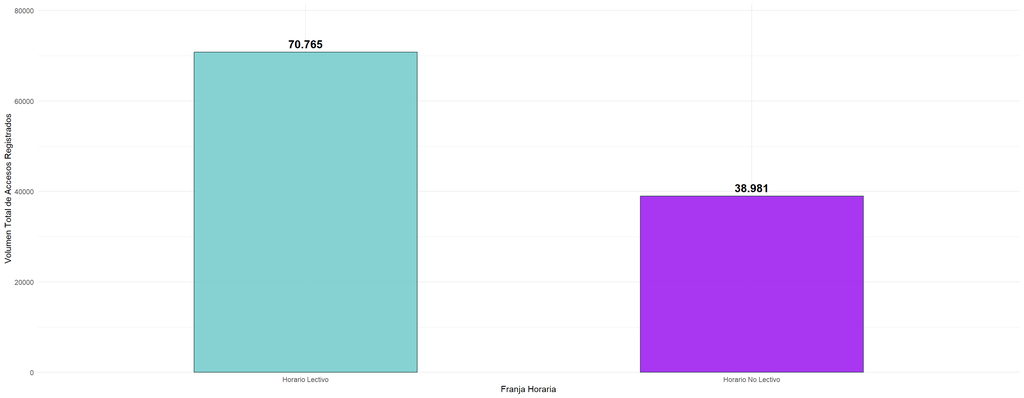

Actividad total en el Aula Virtual por franja horaria.

A la vista de la Tabla $\ref{tab:tabla-dispositivos}$ y la Figura $\ref{fig:figura-dispositivos}$, se puede dar una respuesta fundamentada a la pregunta de investigación planteada: el uso de dispositivos es completamente indiferente respecto al horario. En la base de datos analizada, el alumno utiliza invariablemente el entorno Web/Ordenador.

Lo que sí experimenta una variación altamente significativa no es la herramienta, sino la intensidad de uso. La Figura $\ref{fig:figura-dispositivos}$ evidencia que el volumen de interacciones se desploma casi a la mitad (pasando de más de 70.000 a cerca de 39.000) al salir del horario de clase. Esto permite concluir que, aunque el dispositivo no cambia, los estudiantes concentran su actividad digital en la franja matutina presencial, dejando el horario no lectivo para un acceso considerablemente más residual.

## 10.7 Análisis de la actividad según el tipo de día y momento del curso

Para comprender los hábitos de estudio del alumnado, es fundamental analizar cómo se distribuye su carga de trabajo entre los días laborales y los fines de semana. Además, resulta de gran interés comprobar si esta proporción se mantiene estable a lo largo del año o si, por el contrario, se ve alterada ante la proximidad de fechas clave (como la entrega de proyectos o exámenes).

Para responder a esta cuestión, utilizamos la información temporal de los eventos para identificar el día exacto de la semana en que ocurrieron. Posteriormente, dividimos el histórico del curso en dos fases: un Periodo Regular y una Época de Entrega (definida como los 14 días previos a la entrega final del proyecto fijada el 26 de mayo).

Distribución de la actividad en días laborales y fines de semana según la fase del curso.

| Fase_Curso | Tipo_Dia | Accesos | Porcentaje |
| --- | --- | --- | --- |
| Periodo Regular | Fin de Semana (S-D) | 7321 | 7.66 |
| Periodo Regular | Laboral (L-V) | 88232 | 92.34 |
| Época de Entrega | Fin de Semana (S-D) | 3746 | 26.39 |
| Época de Entrega | Laboral (L-V) | 10447 | 73.61 |

Al analizar la Tabla $\ref{tab:tabla-dias}$, debemos tener en cuenta un factor estadístico clave: una semana se compone de 5 días laborales y 2 de fin de semana. Por tanto, un reparto equitativo y perfectamente proporcional del trabajo implicaría, de base, un ~71% de actividad laboral y un ~29% en fin de semana.

Para interpretar correctamente cómo los estudiantes alteran este balance natural según el momento del curso, se ha diseñado la siguiente visualización comparativa.

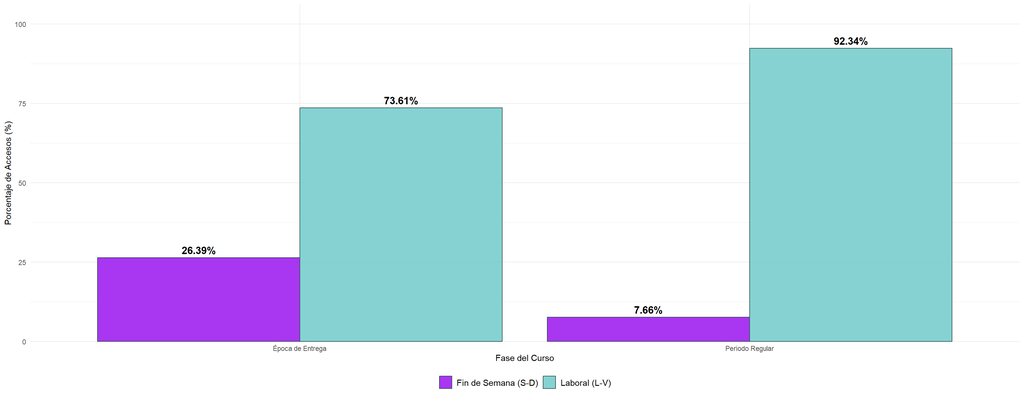

Comparativa porcentual de accesos entre días laborales y fines de semana.

La Figura $\ref{fig:figura-dias}$ responde claramente a la hipótesis planteada. De forma general, existe mucha más actividad durante los días laborales, algo lógico al ser los días en los que se imparte docencia y los estudiantes asisten al campus. Durante el “Periodo Regular”, el fin de semana registra una actividad residual, evidenciando que el alumnado utiliza estos días principalmente para el descanso y la desconexión académica.

Sin embargo, esta proporción varía drásticamente al analizar momentos concretos. Al llegar la “Época de Entrega”, la gráfica muestra un notable trasvase porcentual: el peso del fin de semana (representado por las barras en color morado) se incrementa considerablemente a costa de la actividad entre semana. Este aumento demuestra que, bajo la presión de los plazos de evaluación o exámenes, los estudiantes se ven obligados a sacrificar sus días de descanso y convertir los fines de semana en jornadas intensivas de estudio y trabajo en la plataforma.